# Week 7 Work

Arin Vansomphone

2022-08-05

# Working with the data

```r
# loading the packages
library(tidyverse)
library(readxl)
```

```r
# loading the data
bloodpressure <- read_csv("bloodpressure.csv")
hba1c <- read_csv("hba1c.csv")
AG <- read_xlsx("UCLA Samples-2022-07-19 Summary.xlsx", sheet = "Summary",
                skip = 7) %>%
  rename(BSI_ID = `Sample ID`)
linkfile <- read_csv("zhou_7816_linkfile.csv")
accord_key <- read_csv("accord_key.csv")
microvascularoutcomes <- read_csv("microvascularoutcomes.csv")
cvdoutcomes <- read_csv("cvdoutcomes.csv")
```

```r
f07_baseline <- read_csv("f07_baselinehistoryphysicalexam.csv")
otherlabs <- read_csv("otherlabs.csv")
AG
```

```
## # A tibble: 4,000 × 6
##    `R2020 000036` `Sample #` BSI_ID        `Rep 1` `Rep 2`  Mean
##    <chr>               <dbl> <chr>           <dbl>   <dbl> <dbl>
##  1 Box 1                   1 KB 010495 001    12      12.1  12.0
##  2 Box 1                   2 KB 036551 001    19.9    19.7  19.8
##  3 Box 1                   3 KB 011404 001    13.8    13.4  13.6
##  4 Box 1                   4 KB 034788 001    17.5    17.7  17.6
##  5 Box 1                   5 KB 010382 001    17.3    17.5  17.4
##  6 Box 1                   6 KB 013283 001    27      26.7  26.8
##  7 Box 1                   7 KB 011444 001     9.3     9.7   9.5
##  8 Box 1                   8 KB 040903 001    23.3    23.2  23.2
##  9 Box 1                   9 KB 021249 001    13.4    13.3  13.4
## 10 Box 1                  10 KB 029172 001    43.5    44.1  43.8
## # … with 3,990 more rows
```

```r
# tidying the data
AG <- AG %>% #linking MASKID to Batch ID
  full_join(linkfile, by = "BSI_ID") %>%
  filter(!is.na(MASKID) ) %>%
  rename(MaskID = MASKID,
         Box = `R2020 000036`)
AG
```

```
## # A tibble: 4,000 × 7
##    Box   `Sample #` BSI_ID        `Rep 1` `Rep 2`  Mean MaskID
##    <chr>      <dbl> <chr>           <dbl>   <dbl> <dbl>  <dbl>
##  1 Box 1          1 KB 010495 001    12      12.1  12.0 101121
##  2 Box 1          2 KB 036551 001    19.9    19.7  19.8 107910
##  3 Box 1          3 KB 011404 001    13.8    13.4  13.6 101341
##  4 Box 1          4 KB 034788 001    17.5    17.7  17.6 107434
##  5 Box 1          5 KB 010382 001    17.3    17.5  17.4 101093
##  6 Box 1          6 KB 013283 001    27      26.7  26.8 101814
##  7 Box 1          7 KB 011444 001     9.3     9.7   9.5 101354
##  8 Box 1          8 KB 040903 001    23.3    23.2  23.2 109136
##  9 Box 1          9 KB 021249 001    13.4    13.3  13.4 103931
## 10 Box 1         10 KB 029172 001    43.5    44.1  43.8 105989
## # … with 3,990 more rows
```

```r
# creating a BatchID column
BatchIDs <- c("R2020 000036", "R2020 000037", "R2020 000038", "R2020 000039",
             "R2020 000040", "R2020 000041", "R2020 000042", "R2020 000043")
index = c(1, which(AG$Box %in% BatchIDs), 4001)
BatchID_col = rep(BatchIDs, diff(index))
AG <- AG %>% mutate(BatchID = BatchID_col) %>%
  relocate(BatchID, .before = Box) %>%
  relocate(MaskID, .after = BSI_ID)
AG
```

```
## # A tibble: 4,000 × 8
##    BatchID      Box   `Sample #` BSI_ID        MaskID `Rep 1` `Rep 2`  Mean
##    <chr>        <chr>      <dbl> <chr>          <dbl>   <dbl>   <dbl> <dbl>
##  1 R2020 000036 Box 1          1 KB 010495 001 101121    12      12.1  12.0
##  2 R2020 000036 Box 1          2 KB 036551 001 107910    19.9    19.7  19.8
##  3 R2020 000036 Box 1          3 KB 011404 001 101341    13.8    13.4  13.6
##  4 R2020 000036 Box 1          4 KB 034788 001 107434    17.5    17.7  17.6
##  5 R2020 000036 Box 1          5 KB 010382 001 101093    17.3    17.5  17.4
##  6 R2020 000036 Box 1          6 KB 013283 001 101814    27      26.7  26.8
##  7 R2020 000036 Box 1          7 KB 011444 001 101354     9.3     9.7   9.5
##  8 R2020 000036 Box 1          8 KB 040903 001 109136    23.3    23.2  23.2
##  9 R2020 000036 Box 1          9 KB 021249 001 103931    13.4    13.3  13.4
## 10 R2020 000036 Box 1         10 KB 029172 001 105989    43.5    44.1  43.8
## # … with 3,990 more rows
```

```r
# replacing errors in Box
AG["Box"][AG["Box"] == "R2020 000037"] <- "Box 1"
AG["Box"][AG["Box"] == "R2020 000038"] <- "Box 1"
AG["Box"][AG["Box"] == "R2020 000039"] <- "Box 1"
AG["Box"][AG["Box"] == "R2020 000040"] <- "Box 1"
AG["Box"][AG["Box"] == "R2020 000041"] <- "Box 1"
AG["Box"][AG["Box"] == "R2020 000042"] <- "Box 1"
AG["Box"][AG["Box"] == "R2020 000043"] <- "Box 1"
AG
```

```
## # A tibble: 4,000 × 8
##    BatchID      Box   `Sample #` BSI_ID        MaskID `Rep 1` `Rep 2`  Mean
##    <chr>        <chr>      <dbl> <chr>          <dbl>   <dbl>   <dbl> <dbl>
##  1 R2020 000036 Box 1          1 KB 010495 001 101121    12      12.1  12.0
##  2 R2020 000036 Box 1          2 KB 036551 001 107910    19.9    19.7  19.8
##  3 R2020 000036 Box 1          3 KB 011404 001 101341    13.8    13.4  13.6
##  4 R2020 000036 Box 1          4 KB 034788 001 107434    17.5    17.7  17.6
##  5 R2020 000036 Box 1          5 KB 010382 001 101093    17.3    17.5  17.4
##  6 R2020 000036 Box 1          6 KB 013283 001 101814    27      26.7  26.8
##  7 R2020 000036 Box 1          7 KB 011444 001 101354     9.3     9.7   9.5
##  8 R2020 000036 Box 1          8 KB 040903 001 109136    23.3    23.2  23.2
##  9 R2020 000036 Box 1          9 KB 021249 001 103931    13.4    13.3  13.4
## 10 R2020 000036 Box 1         10 KB 029172 001 105989    43.5    44.1  43.8
## # … with 3,990 more rows
```

```r
# joining hba1c with the AG dataframe
AG <- AG %>%
  inner_join(hba1c, by = "MaskID")
AG
```

```
## # A tibble: 59,036 × 10
##    BatchID      Box   `Sample #` BSI_ID MaskID `Rep 1` `Rep 2`  Mean Visit hba1c
##    <chr>        <chr>      <dbl> <chr>   <dbl>   <dbl>   <dbl> <dbl> <chr> <dbl>
##  1 R2020 000036 Box 1          1 KB 01… 101121      12    12.1  12.0 BLR     7
##  2 R2020 000036 Box 1          1 KB 01… 101121      12    12.1  12.0 F04     6.6
##  3 R2020 000036 Box 1          1 KB 01… 101121      12    12.1  12.0 F08     6
##  4 R2020 000036 Box 1          1 KB 01… 101121      12    12.1  12.0 F12     5.4
##  5 R2020 000036 Box 1          1 KB 01… 101121      12    12.1  12.0 F16     5.8
##  6 R2020 000036 Box 1          1 KB 01… 101121      12    12.1  12.0 F20     6.1
##  7 R2020 000036 Box 1          1 KB 01… 101121      12    12.1  12.0 F24     6
##  8 R2020 000036 Box 1          1 KB 01… 101121      12    12.1  12.0 F28     5.7
##  9 R2020 000036 Box 1          1 KB 01… 101121      12    12.1  12.0 F32     6.2
## 10 R2020 000036 Box 1          1 KB 01… 101121      12    12.1  12.0 F36     6.3
## # … with 59,026 more rows
```

```r
# joining the accord key and f07 baseline dataframes
AG <- AG %>%
 left_join(accord_key, by= "MaskID") %>%
 left_join(f07_baseline, by = "MaskID")
AG
```

```
## # A tibble: 59,036 × 78
##    BatchID    Box   `Sample #` BSI_ID MaskID `Rep 1` `Rep 2`  Mean Visit.x hba1c
##    <chr>      <chr>      <dbl> <chr>   <dbl>   <dbl>   <dbl> <dbl> <chr>   <dbl>
##  1 R2020 000… Box 1          1 KB 01… 101121      12    12.1  12.0 BLR       7
##  2 R2020 000… Box 1          1 KB 01… 101121      12    12.1  12.0 F04       6.6
##  3 R2020 000… Box 1          1 KB 01… 101121      12    12.1  12.0 F08       6
##  4 R2020 000… Box 1          1 KB 01… 101121      12    12.1  12.0 F12       5.4
##  5 R2020 000… Box 1          1 KB 01… 101121      12    12.1  12.0 F16       5.8
##  6 R2020 000… Box 1          1 KB 01… 101121      12    12.1  12.0 F20       6.1
##  7 R2020 000… Box 1          1 KB 01… 101121      12    12.1  12.0 F24       6
##  8 R2020 000… Box 1          1 KB 01… 101121      12    12.1  12.0 F28       5.7
##  9 R2020 000… Box 1          1 KB 01… 101121      12    12.1  12.0 F32       6.2
## 10 R2020 000… Box 1          1 KB 01… 101121      12    12.1  12.0 F36       6.3
## # … with 59,026 more rows, and 68 more variables: female <dbl>,
## #   baseline_age <dbl>, arm <dbl>, treatment <chr>, trial_elig <dbl>,
## #   cvd_hx_baseline <dbl>, network <dbl>, raceclass <chr>, Visit.y <chr>,
## #   livealon <dbl>, edu <dbl>, yrsdiab <dbl>, yrslipi <dbl>, yrstens <dbl>,
## #   ulcer <dbl>, protein <dbl>, hartfail <dbl>, neuropat <dbl>, depressn <dbl>,
## #   eyedisea <dbl>, histhart <dbl>, cigarett <dbl>, smokelif <dbl>,
## #   quityrs <dbl>, alcohol <dbl>, ins_cover <dbl>, dk_unins <dbl>, …
```

```r
# creating glycemic, bp, and lipid arm variables
AG <- AG %>%
mutate(glycemic_arm = ifelse(arm==1|arm==2|arm==5|arm==6,0,1),
         bp_arm = ifelse(arm==3 | arm ==1, 1, 0),
         lipid_arm = ifelse(arm==7 | arm == 5, 1, 0))
AG
```

```
## # A tibble: 59,036 × 81
##    BatchID    Box   `Sample #` BSI_ID MaskID `Rep 1` `Rep 2`  Mean Visit.x hba1c
##    <chr>      <chr>      <dbl> <chr>   <dbl>   <dbl>   <dbl> <dbl> <chr>   <dbl>
##  1 R2020 000… Box 1          1 KB 01… 101121      12    12.1  12.0 BLR       7
##  2 R2020 000… Box 1          1 KB 01… 101121      12    12.1  12.0 F04       6.6
##  3 R2020 000… Box 1          1 KB 01… 101121      12    12.1  12.0 F08       6
##  4 R2020 000… Box 1          1 KB 01… 101121      12    12.1  12.0 F12       5.4
##  5 R2020 000… Box 1          1 KB 01… 101121      12    12.1  12.0 F16       5.8
##  6 R2020 000… Box 1          1 KB 01… 101121      12    12.1  12.0 F20       6.1
##  7 R2020 000… Box 1          1 KB 01… 101121      12    12.1  12.0 F24       6
##  8 R2020 000… Box 1          1 KB 01… 101121      12    12.1  12.0 F28       5.7
##  9 R2020 000… Box 1          1 KB 01… 101121      12    12.1  12.0 F32       6.2
## 10 R2020 000… Box 1          1 KB 01… 101121      12    12.1  12.0 F36       6.3
## # … with 59,026 more rows, and 71 more variables: female <dbl>,
## #   baseline_age <dbl>, arm <dbl>, treatment <chr>, trial_elig <dbl>,
## #   cvd_hx_baseline <dbl>, network <dbl>, raceclass <chr>, Visit.y <chr>,
## #   livealon <dbl>, edu <dbl>, yrsdiab <dbl>, yrslipi <dbl>, yrstens <dbl>,
## #   ulcer <dbl>, protein <dbl>, hartfail <dbl>, neuropat <dbl>, depressn <dbl>,
## #   eyedisea <dbl>, histhart <dbl>, cigarett <dbl>, smokelif <dbl>,
## #   quityrs <dbl>, alcohol <dbl>, ins_cover <dbl>, dk_unins <dbl>, …
```

```r
# creating the kidney variable
baseline_ualb <- otherlabs %>%
  filter(Visit == "BLR") %>%
  mutate(kidney = ifelse(gfr < 45 | ualb > 300, 1, 0)) %>%
  select(MaskID, -Visit, kidney)
baseline_ualb
```

```
## # A tibble: 10,240 × 2
##    MaskID kidney
##     <dbl>  <dbl>
##  1 100001      0
##  2 100002      0
##  3 100003      0
##  4 100004      0
##  5 100005      0
##  6 100006      0
##  7 100007      0
##  8 100008      0
##  9 100009      0
## 10 100010      0
## # … with 10,230 more rows
```

```r
# joining the kidney variable with the main dataframe
AG <- AG %>%
  inner_join(baseline_ualb, by = "MaskID")
AG
```

```
## # A tibble: 58,997 × 82
##    BatchID    Box   `Sample #` BSI_ID MaskID `Rep 1` `Rep 2`  Mean Visit.x hba1c
##    <chr>      <chr>      <dbl> <chr>   <dbl>   <dbl>   <dbl> <dbl> <chr>   <dbl>
##  1 R2020 000… Box 1          1 KB 01… 101121      12    12.1  12.0 BLR       7
##  2 R2020 000… Box 1          1 KB 01… 101121      12    12.1  12.0 F04       6.6
##  3 R2020 000… Box 1          1 KB 01… 101121      12    12.1  12.0 F08       6
##  4 R2020 000… Box 1          1 KB 01… 101121      12    12.1  12.0 F12       5.4
##  5 R2020 000… Box 1          1 KB 01… 101121      12    12.1  12.0 F16       5.8
##  6 R2020 000… Box 1          1 KB 01… 101121      12    12.1  12.0 F20       6.1
##  7 R2020 000… Box 1          1 KB 01… 101121      12    12.1  12.0 F24       6
##  8 R2020 000… Box 1          1 KB 01… 101121      12    12.1  12.0 F28       5.7
##  9 R2020 000… Box 1          1 KB 01… 101121      12    12.1  12.0 F32       6.2
## 10 R2020 000… Box 1          1 KB 01… 101121      12    12.1  12.0 F36       6.3
## # … with 58,987 more rows, and 72 more variables: female <dbl>,
## #   baseline_age <dbl>, arm <dbl>, treatment <chr>, trial_elig <dbl>,
## #   cvd_hx_baseline <dbl>, network <dbl>, raceclass <chr>, Visit.y <chr>,
## #   livealon <dbl>, edu <dbl>, yrsdiab <dbl>, yrslipi <dbl>, yrstens <dbl>,
## #   ulcer <dbl>, protein <dbl>, hartfail <dbl>, neuropat <dbl>, depressn <dbl>,
## #   eyedisea <dbl>, histhart <dbl>, cigarett <dbl>, smokelif <dbl>,
## #   quityrs <dbl>, alcohol <dbl>, ins_cover <dbl>, dk_unins <dbl>, …
```

```r
# selecting and filtering the data that we need
AG <- AG %>%
  filter(Visit.x == "F12") %>%
  select(BatchID, Box, MaskID, Mean, hba1c,
         baseline_age, glycemic_arm, bp_arm, lipid_arm,
         female, raceclass, cvd_hx_baseline, yrsdiab,
         hartfail, eyedisea, smokelif, kidney)
AG
```

```
## # A tibble: 3,661 × 17
##    BatchID   Box   MaskID  Mean hba1c baseline_age glycemic_arm bp_arm lipid_arm
##    <chr>     <chr>  <dbl> <dbl> <dbl>        <dbl>        <dbl>  <dbl>     <dbl>
##  1 R2020 00… Box 1 101121  12.0   5.4         74.5            1      0         1
##  2 R2020 00… Box 1 107910  19.8   6.7         57.7            1      0         1
##  3 R2020 00… Box 1 101341  13.6   6.3         68              1      0         0
##  4 R2020 00… Box 1 107434  17.6   6.9         76.1            1      1         0
##  5 R2020 00… Box 1 101093  17.4   6.7         64.7            0      1         0
##  6 R2020 00… Box 1 101814  26.8   6.5         62.8            1      0         0
##  7 R2020 00… Box 1 101354   9.5   8.1         63.4            0      0         0
##  8 R2020 00… Box 1 109136  23.2   7.3         62.9            0      1         0
##  9 R2020 00… Box 1 103931  13.4   7.8         70.6            0      0         0
## 10 R2020 00… Box 1 105989  43.8   7.3         57.3            1      1         0
## # … with 3,651 more rows, and 8 more variables: female <dbl>, raceclass <chr>,
## #   cvd_hx_baseline <dbl>, yrsdiab <dbl>, hartfail <dbl>, eyedisea <dbl>,
## #   smokelif <dbl>, kidney <dbl>
```

### Transforming 1,5 AG

### Dealing with batch effects

To deal with the batch effects of the data, I sort my observations into an additional categorical variable, combining batches 36 and 37 and combining the rest of the batches.

```r
group1 = c("R2020 000036", "R2020 000037")

# creating the new variable and assigning values
AG$Group = "2"
AG$Group[AG$BatchID %in% group1] = "1"
AG
```

```
## # A tibble: 3,661 × 18
##    BatchID   Box   MaskID  Mean hba1c baseline_age glycemic_arm bp_arm lipid_arm
##    <chr>     <chr>  <dbl> <dbl> <dbl>        <dbl>        <dbl>  <dbl>     <dbl>
##  1 R2020 00… Box 1 101121  12.0   5.4         74.5            1      0         1
##  2 R2020 00… Box 1 107910  19.8   6.7         57.7            1      0         1
##  3 R2020 00… Box 1 101341  13.6   6.3         68              1      0         0
##  4 R2020 00… Box 1 107434  17.6   6.9         76.1            1      1         0
##  5 R2020 00… Box 1 101093  17.4   6.7         64.7            0      1         0
##  6 R2020 00… Box 1 101814  26.8   6.5         62.8            1      0         0
##  7 R2020 00… Box 1 101354   9.5   8.1         63.4            0      0         0
##  8 R2020 00… Box 1 109136  23.2   7.3         62.9            0      1         0
##  9 R2020 00… Box 1 103931  13.4   7.8         70.6            0      0         0
## 10 R2020 00… Box 1 105989  43.8   7.3         57.3            1      1         0
## # … with 3,651 more rows, and 9 more variables: female <dbl>, raceclass <chr>,
## #   cvd_hx_baseline <dbl>, yrsdiab <dbl>, hartfail <dbl>, eyedisea <dbl>,
## #   smokelif <dbl>, kidney <dbl>, Group <chr>
```

### Comparing baseline covariates with 1,5 AG at 12 months

Now I plot various baseline covariates against the 1,5 AG (`Mean`) column to see if there are any correlations between the variables. I also calculated the pearson coefficient to quantify the correlations.

**Glycemic Arm:**

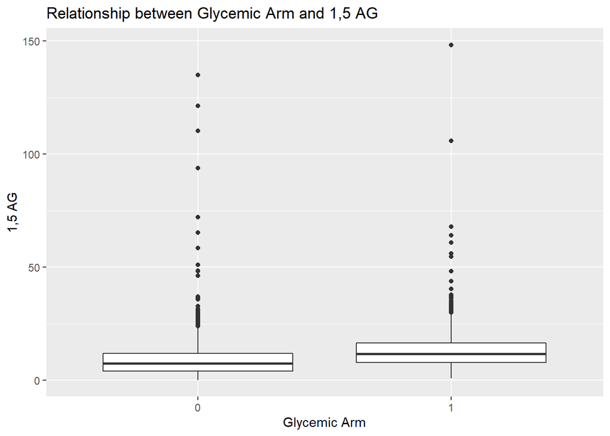

```r
# need to convert variable to a character type first
AG$glycemic_arm <- as.character(AG$glycemic_arm)

# plotting variable against 1,5 AG
AG %>%
  na.omit() %>%
  ggplot(aes(x = glycemic_arm, y = Mean)) +
  geom_boxplot() +
  labs(x = "Glycemic Arm",
       y = "1,5 AG",
       title = "Relationship between Glycemic Arm and 1,5 AG")
```

```r
AG %>%
  na.omit() %>%
  group_by(glycemic_arm) %>%
  summarize(Mean = mean(Mean),
            Median = median(Mean),
            SD = sd(Mean))
```

```
## # A tibble: 2 × 4
##   glycemic_arm  Mean Median    SD
##   <chr>        <dbl>  <dbl> <dbl>
## 1 0             9.20   9.20    NA
## 2 1            12.8   12.8     NA
```

There is no pearson correlation coefficient for this variable because it is categorical.

**BP Arm:**

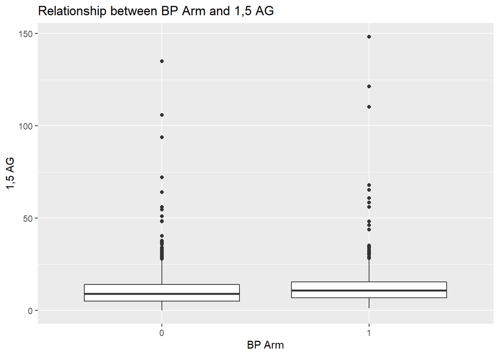

```r
# need to convert variabe to a character type first
AG$bp_arm <- as.character(AG$bp_arm)

# plotting variable against 1,5 AG
AG %>%
  na.omit() %>%
  ggplot(aes(x = bp_arm, y = Mean)) +
  geom_boxplot() +
  labs(x = "BP Arm",
       y = "1,5 AG",
       title = "Relationship between BP Arm and 1,5 AG")
```

```r
AG %>%
  na.omit() %>%
  group_by(bp_arm) %>%
  summarize(Mean = mean(Mean),
            Median = median(Mean),
            SD = sd(Mean))
```

```
## # A tibble: 2 × 4
##   bp_arm  Mean Median    SD
##   <chr>  <dbl>  <dbl> <dbl>
## 1 0       10.5   10.5    NA
## 2 1       12.2   12.2    NA
```

There is no pearson correlation coefficient for this variable because it is categorical.

**Lipid Arm:**

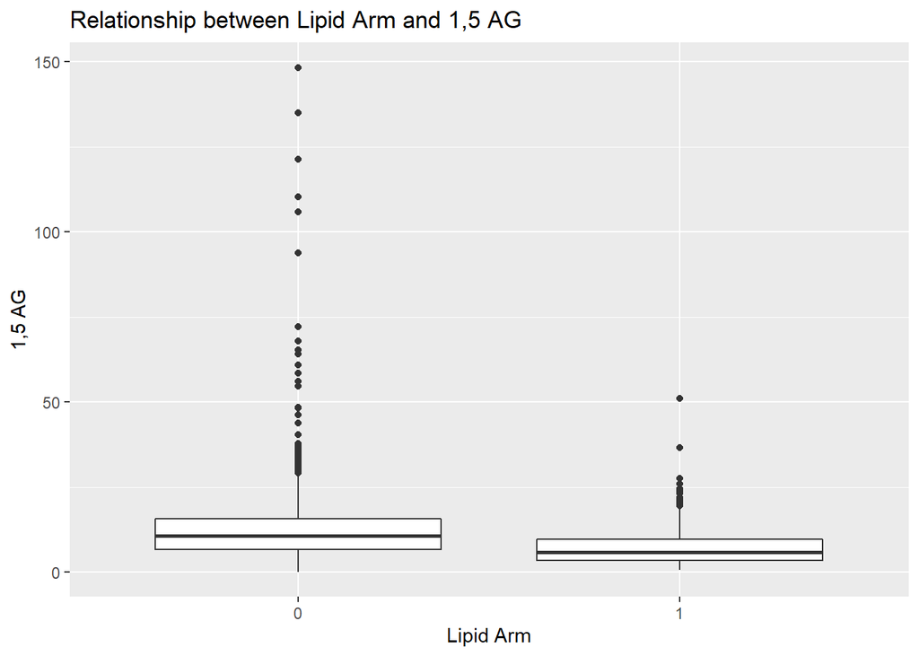

```r
# need to convert variable to a character type first
AG$lipid_arm <- as.character(AG$lipid_arm)

# plotting variable against 1,5 AG
AG %>%
  na.omit() %>%
  ggplot(aes(x = lipid_arm, y = Mean)) +
  geom_boxplot() +
  labs(x = "Lipid Arm",
       y = "1,5 AG",
       title = "Relationship between Lipid Arm and 1,5 AG")
```

```r
AG %>%
  na.omit() %>%
  group_by(lipid_arm) %>%
  summarize(Mean = mean(Mean),
            Median = median(Mean),
            SD = sd(Mean))
```

```
## # A tibble: 2 × 4
##   lipid_arm  Mean Median    SD
##   <chr>     <dbl>  <dbl> <dbl>
## 1 0         12.1   12.1     NA
## 2 1          7.16   7.16    NA
```

There is no pearson correlation coefficient for this variable because it is categorical.

**Gender:**

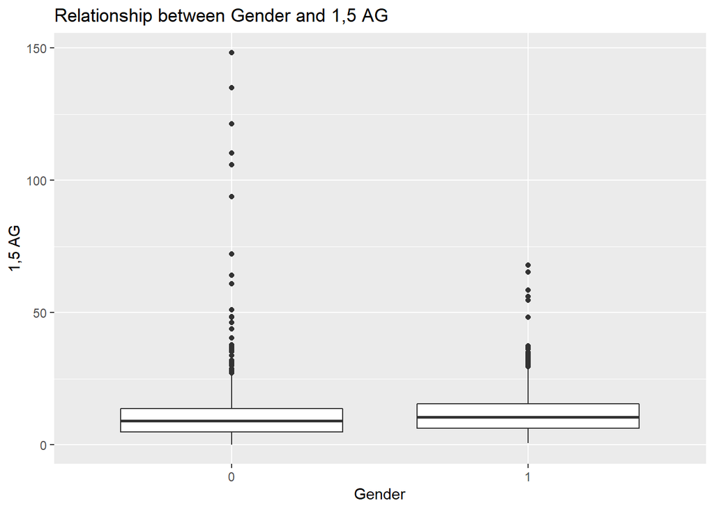

```r
# need to convert variable to a character type first
AG$female <- as.character(AG$female)

# plotting variable against 1,5 AG
AG %>%
  na.omit() %>%
  ggplot(aes(x = female, y = Mean)) +
  geom_boxplot() +
  labs(x = "Gender",
       y = "1,5 AG",
       title = "Relationship between Gender and 1,5 AG")
```

```r
AG %>%
  na.omit() %>%
  group_by(female) %>%
  summarize(Mean = mean(Mean),
            Median = median(Mean),
            SD = sd(Mean))
```

```
## # A tibble: 2 × 4
##   female  Mean Median    SD
##   <chr>  <dbl>  <dbl> <dbl>
## 1 0       10.5   10.5    NA
## 2 1       11.6   11.6    NA
```

There is no pearson correlation coefficient for this variable because it is categorical.

**Ethnicity:**

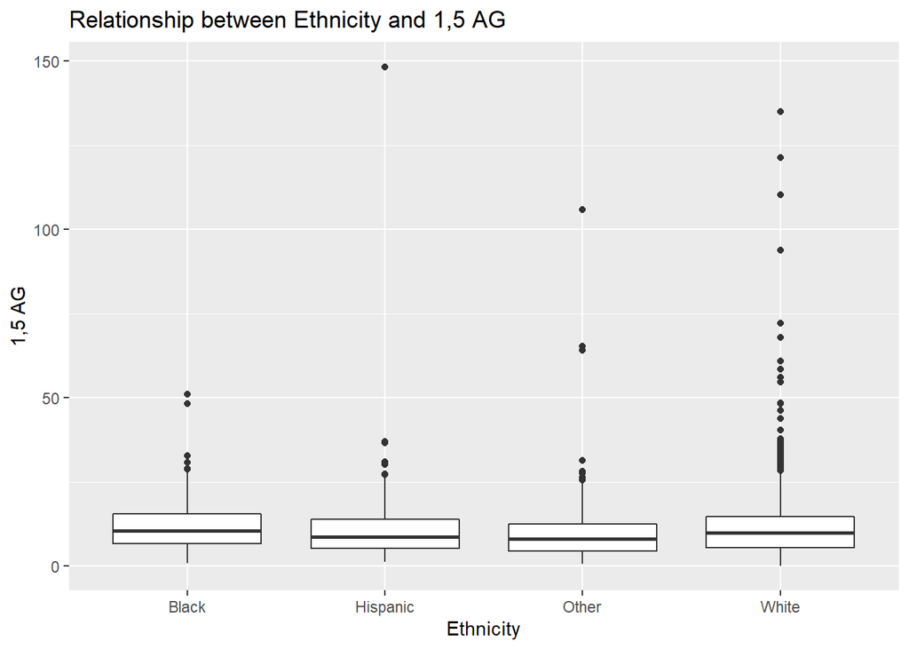

```r
# need to convert variable to a character type first
AG$raceclass <- as.character(AG$raceclass)

# plotting variable against 1,5 AG
AG %>%
  na.omit() %>%
  ggplot(aes(x = raceclass, y = Mean)) +
  geom_boxplot() +
  labs(x = "Ethnicity",
       y = "1,5 AG",
       title = "Relationship between Ethnicity and 1,5 AG")
```

```r
AG %>%
  na.omit() %>%
  group_by(raceclass) %>%
  summarize(Mean = mean(Mean),
            Median = median(Mean),
            SD = sd(Mean))
```

```
## # A tibble: 4 × 4
##   raceclass  Mean Median    SD
##   <chr>     <dbl>  <dbl> <dbl>
## 1 Black     11.4   11.4     NA
## 2 Hispanic  10.9   10.9     NA
## 3 Other      9.47   9.47    NA
## 4 White     11.2   11.2     NA
```

There is no pearson correlation coefficient for this variable because it is categorical.

**CVD HX Baseline:**

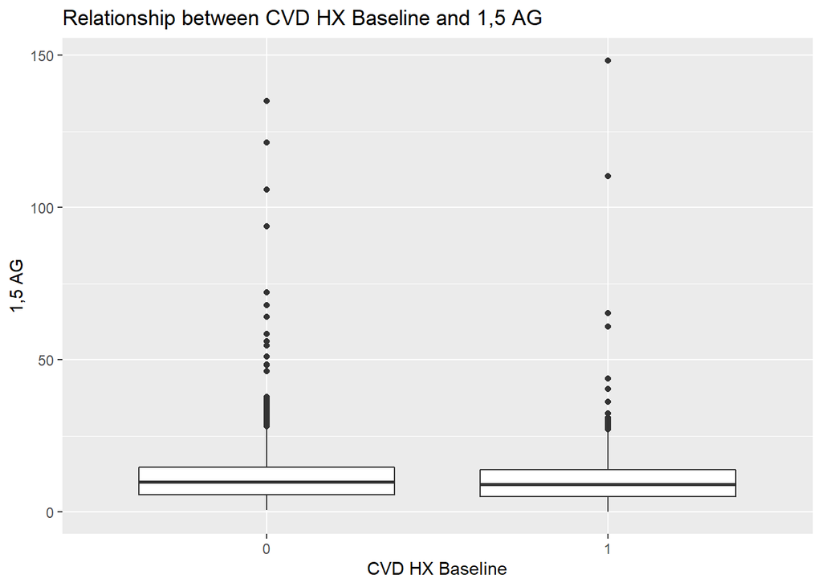

```r
# need to convert variable to a character type first
AG$cvd_hx_baseline <- as.character(AG$cvd_hx_baseline)

# plotting variable against 1,5 AG
AG %>%
  na.omit() %>%
  ggplot(aes(x = cvd_hx_baseline, y = Mean)) +
  geom_boxplot() +
  labs(x = "CVD HX Baseline",
       y = "1,5 AG",
       title = "Relationship between CVD HX Baseline and 1,5 AG")
```

```r
AG %>%
  na.omit() %>%
  group_by(cvd_hx_baseline) %>%
  summarize(Mean = mean(Mean),
            Median = median(Mean),
            SD = sd(Mean))
```

```
## # A tibble: 2 × 4
##   cvd_hx_baseline  Mean Median    SD
##   <chr>           <dbl>  <dbl> <dbl>
## 1 0                11.2   11.2    NA
## 2 1                10.6   10.6    NA
```

There is no pearson correlation coefficient for this variable because it is categorical.

**Eyedisea:**

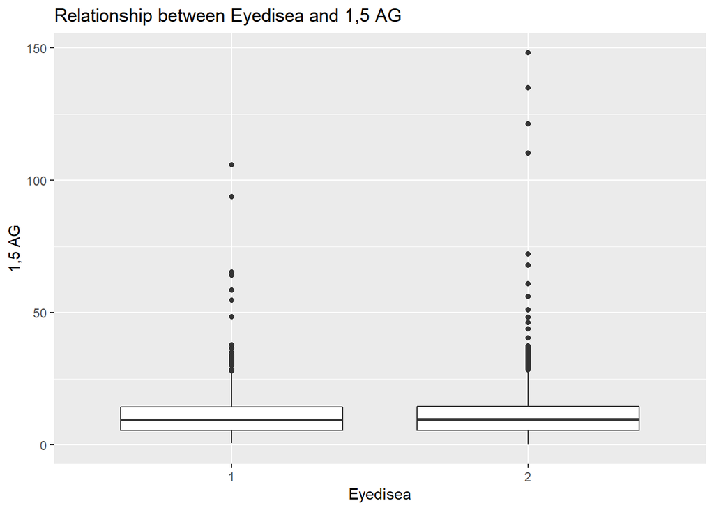

```r
# need to convert variable to a character type first
AG$eyedisea <- as.character(AG$eyedisea)

# plotting variable against 1,5 AG
AG %>%
  na.omit() %>%
  ggplot(aes(x = eyedisea, y = Mean)) +
  geom_boxplot() +
  labs(x = "Eyedisea",
       y = "1,5 AG",
       title = "Relationship between Eyedisea and 1,5 AG")
```

```r
AG %>%
  na.omit() %>%
  group_by(eyedisea) %>%
  summarize(Mean = mean(Mean),
            Median = median(Mean),
            SD = sd(Mean))
```

```
## # A tibble: 2 × 4
##   eyedisea  Mean Median    SD
##   <chr>    <dbl>  <dbl> <dbl>
## 1 1         10.9   10.9    NA
## 2 2         11.1   11.1    NA
```

There is no pearson correlation coefficient for this variable because it is categorical.

**Smokelif:**

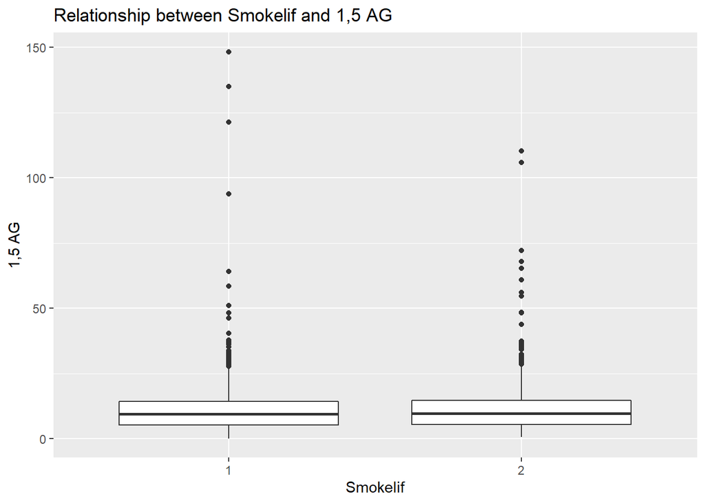

```r
# need to convert variable to a character type first
AG$smokelif <- as.character(AG$smokelif)

# plotting variable against 1,5 AG
AG %>%
  na.omit() %>%
  ggplot(aes(x = smokelif, y = Mean)) +
  geom_boxplot() +
  labs(x = "Smokelif",
       y = "1,5 AG",
       title = "Relationship between Smokelif and 1,5 AG")
```

```r
AG %>%
  na.omit() %>%
  group_by(eyedisea) %>%
  summarize(Mean = mean(Mean),
            Median = median(Mean),
            SD = sd(Mean))
```

```
## # A tibble: 2 × 4
##   eyedisea  Mean Median    SD
##   <chr>    <dbl>  <dbl> <dbl>
## 1 1         10.9   10.9    NA
## 2 2         11.1   11.1    NA
```

There is no pearson correlation coefficient for this variable because it is categorical.

**Kidney:**

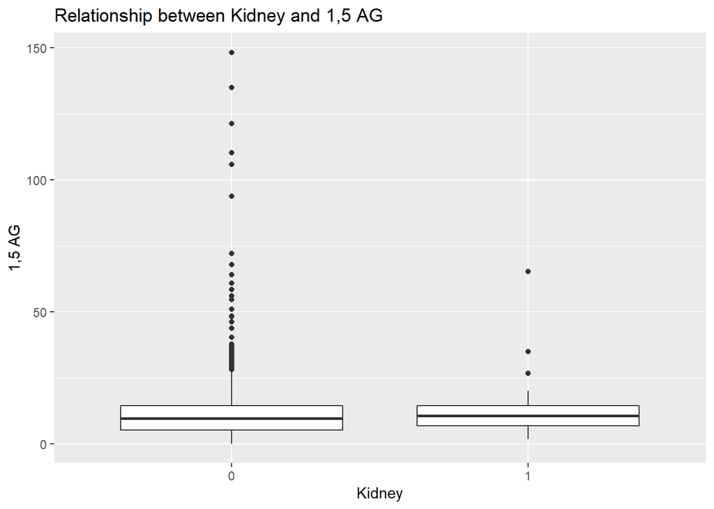

```r
# need to convert variable to a character type first
AG$kidney <- as.character(AG$kidney)

# plotting variable against 1,5 AG
AG %>%
  na.omit() %>%
  ggplot(aes(x = kidney, y = Mean)) +
  geom_boxplot() +
  labs(x = "Kidney",
       y = "1,5 AG",
       title = "Relationship between Kidney and 1,5 AG")
```

```r
AG %>%
  na.omit() %>%
  group_by(kidney) %>%
  summarize(Mean = mean(Mean),
            Median = median(Mean),
            SD = sd(Mean))
```

```
## # A tibble: 2 × 4
##   kidney  Mean Median    SD
##   <chr>  <dbl>  <dbl> <dbl>
## 1 0       11.0   11.0    NA
## 2 1       11.8   11.8    NA
```

There is no pearson correlation coefficient for this variable because it is categorical.

**Heart Failure:**

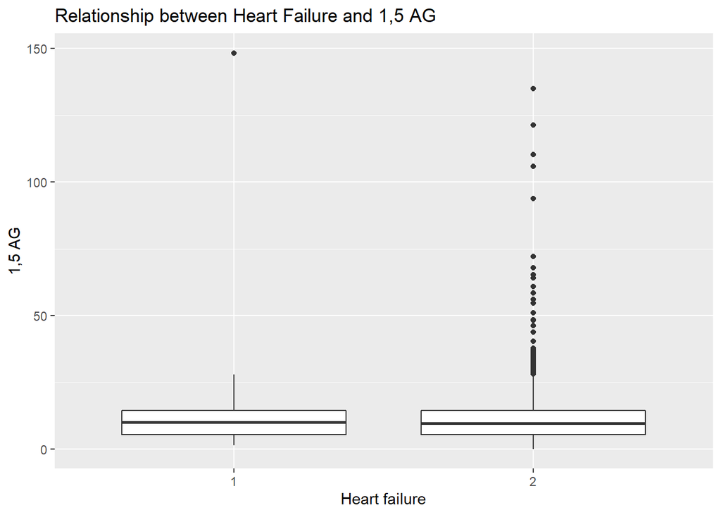

```r
# need to convert variable to a character type first
AG$hartfail <- as.character(AG$hartfail)

# plotting variable against 1,5 AG
AG %>%
  na.omit() %>%
  ggplot(aes(x = hartfail, y = Mean)) +
  geom_boxplot() +
  labs(x = "Heart failure",
       y = "1,5 AG",
       title = "Relationship between Heart Failure and 1,5 AG")
```

```r
AG %>%
  na.omit() %>%
  group_by(hartfail) %>%
  summarize(Mean = mean(Mean),
            Median = median(Mean),
            SD = sd(Mean))
```

```
## # A tibble: 2 × 4
##   hartfail  Mean Median    SD
##   <chr>    <dbl>  <dbl> <dbl>
## 1 1         11.5   11.5    NA
## 2 2         11.0   11.0    NA
```

There is no pearson correlation coefficient for this variable because it is categorical.

**Yrsdiab:**

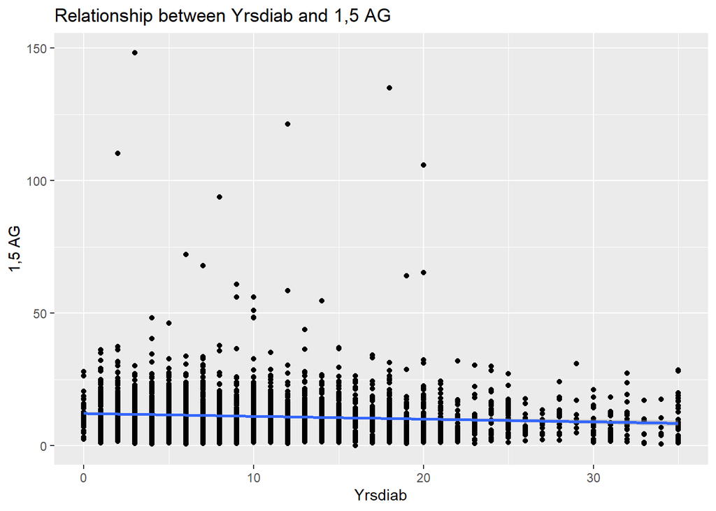

```r
AG %>%
  na.omit() %>%
  ggplot(aes(x = yrsdiab, y = Mean)) +
  geom_point() +
  geom_smooth(method = lm, se = TRUE) +
  labs(x = "Yrsdiab",
       y = "1,5 AG",
       title = "Relationship between Yrsdiab and 1,5 AG")
```

```r
# calculating the pearson coefficient
library(ggpubr)
cor.test(AG$yrsdiab, AG$Mean, method = "pearson")
```

```
##
##  Pearson's product-moment correlation
##
## data:  AG$yrsdiab and AG$Mean
## t = -5.2506, df = 3634, p-value = 1.603e-07
## alternative hypothesis: true correlation is not equal to 0
## 95 percent confidence interval:
##  -0.1189419 -0.0544191
## sample estimates:
##         cor
## -0.08677151
```

The pearson coefficient between `yrsdiab` and `Mean` is -0.087.

# Summary

- Glycemic Arm
- BP Arm
- Lipid Arm
- Gender has a slight effect on 1,5 AG levels. Men tend to have slightly lower 1,5 AG levels than women.
- Blacks, Hispanics, and Whites all have similar 1,5 AG levels. However, other ethnicities have lower 1,5 AG levels than the previously mentioned groups.
- CVD HX baseline has no observable effect on 1,5 AG levels.
- Eye diseases have no observable effect on 1,5 AG levels.
- Smoke life has no observable effect on 1,5 AG levels.
- Kidney appears to have no observable effect on 1,5 AG levels, although more data is needed to strengthen this statement.
- Heart failure appears to have no observable effect on 1,5 AG levels, although more data is needed to strengthen this statement.
- Years of diabetes has no observable effect on 1,5 AG levels.

# Bonus: Running a cox regression with baseline age and 1,5 AG

To run a cox regression and create a survival curve, we are going to take the `censor_tm` and `fuyrs_tm7p` variables that are part of the cvdoutcomes dataframe as our time and status variables. I looked their definitions up using the ACCORD key dictionary.

```r
# loading the necessary package
library(survival)
library(survminer)
# selecting the fuyrs variables
survivalvariables <- cvdoutcomes %>%
  select(MaskID, fuyrs_tm, censor_tm)
survivalvariables
```

```
## # A tibble: 10,251 × 3
##    MaskID fuyrs_tm censor_tm
##     <dbl>    <dbl>     <dbl>
##  1 100001     7            1
##  2 100002     7            1
##  3 100003     6.16         1
##  4 100004     7            1
##  5 100005     4.92         1
##  6 100006     4.51         1
##  7 100007     5.69         1
##  8 100008     4.96         1
##  9 100009     7            1
## 10 100010     4.98         1
## # … with 10,241 more rows
```

```r
# renaming and manipulating
survivalvariables <- survivalvariables %>%
  rename(time = fuyrs_tm) %>%
  mutate(status = ifelse(censor_tm==1, 1, 2)) %>%
  select(MaskID, time, status)
survivalvariables
```

```
## # A tibble: 10,251 × 3
##    MaskID  time status
##     <dbl> <dbl>  <dbl>
##  1 100001  7         1
##  2 100002  7         1
##  3 100003  6.16      1
##  4 100004  7         1
##  5 100005  4.92      1
##  6 100006  4.51      1
##  7 100007  5.69      1
##  8 100008  4.96      1
##  9 100009  7         1
## 10 100010  4.98      1
## # … with 10,241 more rows
```

```r
# adding the survivalvariables to the main data frame
AG <- AG %>%
  inner_join(survivalvariables, by = "MaskID")
AG
```

```
## # A tibble: 3,661 × 20
##    BatchID   Box   MaskID  Mean hba1c baseline_age glycemic_arm bp_arm lipid_arm
##    <chr>     <chr>  <dbl> <dbl> <dbl>        <dbl> <chr>        <chr>  <chr>
##  1 R2020 00… Box 1 101121  12.0   5.4         74.5 1            0      1
##  2 R2020 00… Box 1 107910  19.8   6.7         57.7 1            0      1
##  3 R2020 00… Box 1 101341  13.6   6.3         68   1            0      0
##  4 R2020 00… Box 1 107434  17.6   6.9         76.1 1            1      0
##  5 R2020 00… Box 1 101093  17.4   6.7         64.7 0            1      0
##  6 R2020 00… Box 1 101814  26.8   6.5         62.8 1            0      0
##  7 R2020 00… Box 1 101354   9.5   8.1         63.4 0            0      0
##  8 R2020 00… Box 1 109136  23.2   7.3         62.9 0            1      0
##  9 R2020 00… Box 1 103931  13.4   7.8         70.6 0            0      0
## 10 R2020 00… Box 1 105989  43.8   7.3         57.3 1            1      0
## # … with 3,651 more rows, and 11 more variables: female <chr>, raceclass <chr>,
## #   cvd_hx_baseline <chr>, yrsdiab <dbl>, hartfail <chr>, eyedisea <chr>,
## #   smokelif <chr>, kidney <chr>, Group <chr>, time <dbl>, status <dbl>
```

Now we are ready to run our models.

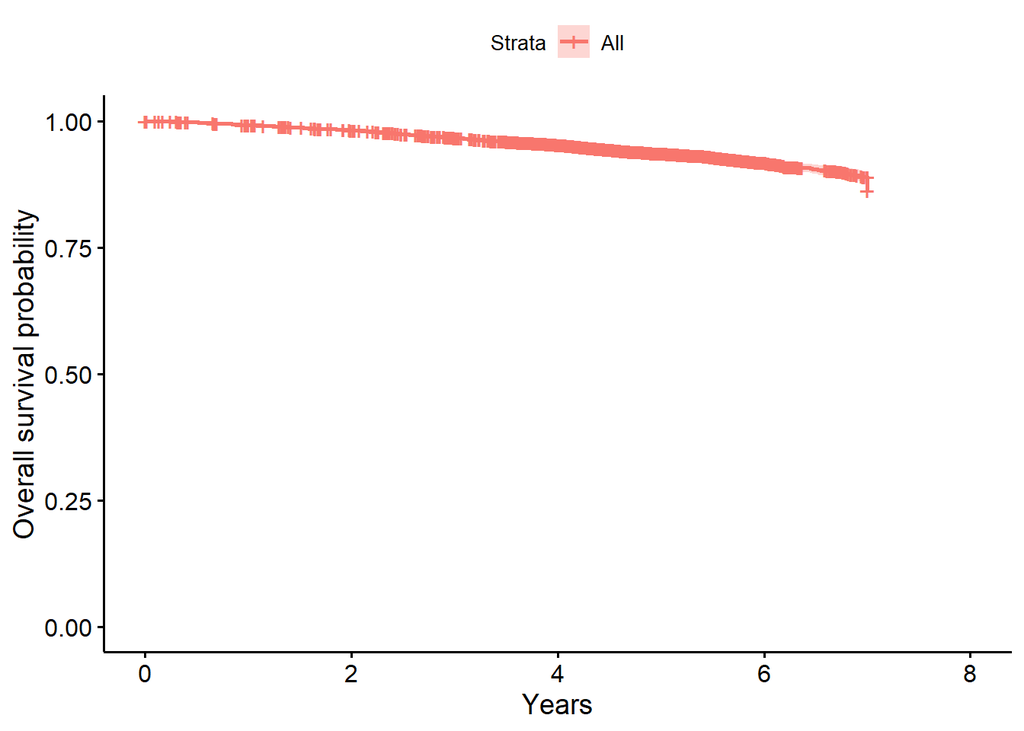

```r
# survival curve:
ggsurvplot(
    fit = survfit(Surv(time, status) ~ 1, data = survivalvariables),
    xlab = "Years",
    ylab = "Overall survival probability")
```

```r
summary(survfit(Surv(time, status) ~ 1, data = survivalvariables), times = 7)
```

```
## Call: survfit(formula = Surv(time, status) ~ 1, data = survivalvariables)
##
##  time n.risk n.event survival std.err lower 95% CI upper 95% CI
##     7    973     718    0.863 0.00749        0.848        0.877
```

According to the data, the survival probability at the end of the study was around 86 percent.

```r
# cox regression model
library(gtsummary)
coxph(Surv(time, status) ~ Mean, data = AG) %>%
  gtsummary::tbl_regression(exp = TRUE)
```

| **Characteristic** | **HR**<sup>1</sup> | **95% CI**<sup>1</sup> | **p-value** |
| --- | --- | --- | --- |
| Mean | 0.99 | 0.97, 1.01 | 0.3 |

<sup>1</sup> HR = Hazard Ratio, CI = Confidence Interval

Since I did not get any definite results, I decided to sort the `Mean` values into 2 groups: normal and abnormal. These groups would be determined by the normal 1,5 AG range of 10.7 to 32.0. I then ran the cox regression again.

```r
AG <- AG %>%
  mutate(Mean_group = ifelse(10.7 <= Mean & Mean <= 32.0, 0, 1))
AG
```

```
## # A tibble: 3,661 × 21
##    BatchID   Box   MaskID  Mean hba1c baseline_age glycemic_arm bp_arm lipid_arm
##    <chr>     <chr>  <dbl> <dbl> <dbl>        <dbl> <chr>        <chr>  <chr>
##  1 R2020 00… Box 1 101121  12.0   5.4         74.5 1            0      1
##  2 R2020 00… Box 1 107910  19.8   6.7         57.7 1            0      1
##  3 R2020 00… Box 1 101341  13.6   6.3         68   1            0      0
##  4 R2020 00… Box 1 107434  17.6   6.9         76.1 1            1      0
##  5 R2020 00… Box 1 101093  17.4   6.7         64.7 0            1      0
##  6 R2020 00… Box 1 101814  26.8   6.5         62.8 1            0      0
##  7 R2020 00… Box 1 101354   9.5   8.1         63.4 0            0      0
##  8 R2020 00… Box 1 109136  23.2   7.3         62.9 0            1      0
##  9 R2020 00… Box 1 103931  13.4   7.8         70.6 0            0      0
## 10 R2020 00… Box 1 105989  43.8   7.3         57.3 1            1      0
## # … with 3,651 more rows, and 12 more variables: female <chr>, raceclass <chr>,
## #   cvd_hx_baseline <chr>, yrsdiab <dbl>, hartfail <chr>, eyedisea <chr>,
## #   smokelif <chr>, kidney <chr>, Group <chr>, time <dbl>, status <dbl>,
## #   Mean_group <dbl>
```

```r
# cox regression model
library(gtsummary)
coxph(Surv(time, status) ~ Mean_group, data = AG) %>%
  gtsummary::tbl_regression(exp = TRUE)
```

| **Characteristic** | **HR**<sup>1</sup> | **95% CI**<sup>1</sup> | **p-value** |
| --- | --- | --- | --- |
| Mean_group | 0.98 | 0.72, 1.35 | >0.9 |

<sup>1</sup> HR = Hazard Ratio, CI = Confidence Interval

Unfortunately, this cox regression model gives me an untrustworthy P-value, so I cannot extract anything meaningful from it. I have to resort to using the first models to create my conclusion, which is that 1,5 AG levels do not have an observable effect on mortality rates.

# Additional work for clinical trial problem

I believe that the data can help us model the patient dropout rate by studying the censored data. Data is censored according to two reasons: a patient drops out of the trial or the studied event does not occur in the patient. Since we are only focused on the first reason of censoring, we can filter the second reason out of the data.

```r
dropoutpatients <- cvdoutcomes %>%
  select(MaskID, fuyrs_po, censor_po)
dropoutpatients
```

```
## # A tibble: 10,251 × 3
##    MaskID fuyrs_po censor_po
##     <dbl>    <dbl>     <dbl>
##  1 100001     7            1
##  2 100002     7            1
##  3 100003     2.00         1
##  4 100004     7            1
##  5 100005     4.92         1
##  6 100006     4.51         1
##  7 100007     5.69         1
##  8 100008     4.96         1
##  9 100009     7            1
## 10 100010     4.98         1
## # … with 10,241 more rows
```

I decided to use the primary outcome based data as that is, as the name suggests, the central element of the clinical trial.

```r
dropoutpatients <- dropoutpatients %>%
  filter(censor_po == 1) %>% # only censored patients, not dead ones
  filter(fuyrs_po != 7) # second reason
```

Now I plot onto a density plot:

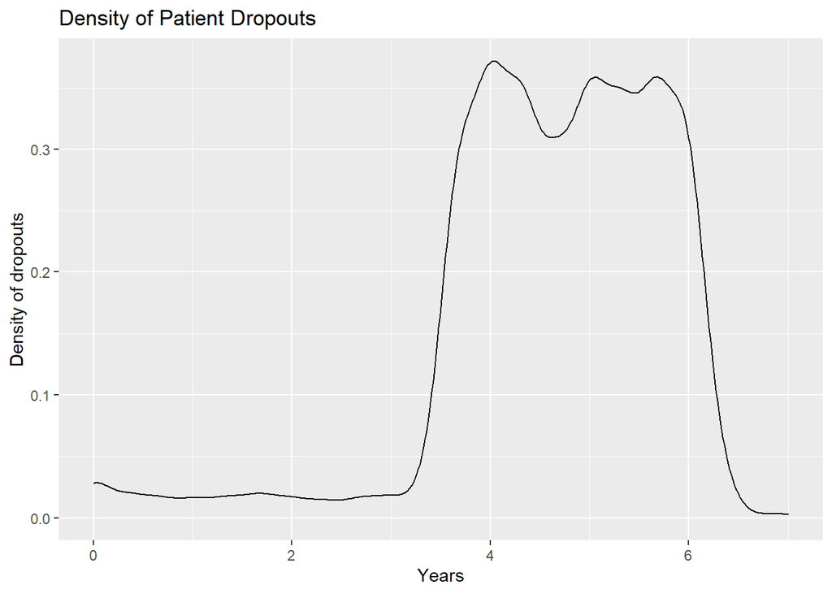

```r
# plotting onto a density plot
dropoutpatients %>%
  na.omit() %>%
  ggplot(aes(x = fuyrs_po)) +
  geom_density() +
  labs(title = "Density of Patient Dropouts",
       x = "Years",
       y = "Density of dropouts")
```

```r
dropoutpatients %>%
  summarize(dropoutpercent = n() / 10251) #10251 is the starting number
```

```
## # A tibble: 1 × 1
##   dropoutpercent
##            <dbl>
## 1          0.816
```